# Wilke et al. richness of endemic diatoms

Three hundred and eighty diatom samples were analysed from the DEEP sediment succession, taken every 128 cm (successive samples are around 2,000–4,000 years apart) between 0 and 406.96 m c.d. and every 64 cm (around 2,000 years) between 406.96 and 446.65 m c.d. The higher sampling frequency in the early phase of Lake Ohrid was chosen because this period was environmentally very dynamic (Wagner et al. 2017, Panagiotopoulos et al. 2020=. For comparison, we also analysed 123 samples from the phase before 1.36 Myr ago (446.65–583.92 m c.d.).

```r
# Load required packages
library(coda)
library(foreach)
library(doParallel)

# Auxiliary functions
source("PyRate/pyrate_utilities.r")
source("AuxiliaryFunctions/lttFromMcmcLog.R")
```

```r
# Read data
Diatoms <- read.table("Data/Supplementary material_Diatoms.csv",
                      sep = "\t", header = TRUE, check.names = FALSE,
                      stringsAsFactors = FALSE)
# Exclude the endemic species we haven't found
Diatoms <- Diatoms[, -c(373:421)]
# Data cleaning
TaxonomyLifestyle <- Diatoms[1:12, -c(1:4)]
Diatoms <- Diatoms[-c(1:12), - c(1:3, 5)]
# Convert to numeric
Diatoms <- as.data.frame( apply(Diatoms, 2, as.numeric) )
# PyRate does not like special characters for species names:
SpeciesChangeNames <- data.frame(Species = colnames(Diatoms)[-1],
                                 SpeciesPyRate = sprintf("SP_%03d", 1:(ncol(Diatoms)-1)),
                                 stringsAsFactors = FALSE)
colnames(Diatoms) <- c("Age", SpeciesChangeNames$SpeciesPyRate)
TaxonomyLifestyle <- rbind(TaxonomyLifestyle, rep(NA, ncol(TaxonomyLifestyle)))
TaxonomyLifestyle[13, ] <- c("PyRateCode", SpeciesChangeNames$SpeciesPyRate)

# Endemic species
SpEndemic <- colnames(Diatoms)[-1][TaxonomyLifestyle[12, -1] == "Endemic"]
# Extinct endemic species
SpEx <- colnames(Diatoms)[-1][TaxonomyLifestyle[11, -1] == "Extinct" &
                              TaxonomyLifestyle[12, -1] == "Endemic"]
```

### Generate PyRate input

As described previously (Pires et al. 2018), the BDS analyses were informed on the endemic species that originated in the basin before the formation of Lake Ohrid 1.36 Myr ago and lack a robust age-control. They therefore did not factor in as speciation events, but the respective 11 extinction events were considered, as they took place 1.36–0 Myr ago.

```r
SpeciationAfter136 <- rep(0, length(SpEndemic))
ExtinctionAfter136 <- SpeciationAfter136
Exclude <- SpeciationAfter136
for(i in 1:length(SpEndemic)){
  Tmp <- Diatoms[, c("Age", SpEndemic[i])]
  Observation <- which(Tmp[, 2] > 0)
  FirstObservation <- Tmp$Age[max(Observation)]
  LastObservation <- Tmp$Age[min(Observation)]
  # Speciation between 1.36-0 Myr ago
  if(!is.na(FirstObservation)){
    SpeciationAfter136[i] <- 1
  }
  # Extinction between 1.36-0 Myr ago
  if(!is.na(LastObservation) & SpEndemic[i] %in% SpEx){
    ExtinctionAfter136[i] <- 1
  }
  # First and last observation before 1.36 Myr;
  # no matter whether they are extant or extinct
  # (Those species are not informative and do not contribute to the likelihood)
  if(is.na(FirstObservation) & is.na(LastObservation)){
    Exclude[i] <- 1
  }
}
AliveBefore <- data.frame(taxon = SpEndemic,
                          speciation_in_bin = SpeciationAfter136,
                          extinction_in_bin = ExtinctionAfter136)
AliveBefore <- AliveBefore[Exclude == 0, ]
write.table(AliveBefore, "BDS/AliveBefore.txt",
            sep = "\t", row.names = FALSE, col.names = TRUE, quote = FALSE)
```

Due to computational limits we only generate 2 randomized inputs for this reproducible example.

```r
set.seed(23) # Reproducibility

DiaTrim <- Diatoms[, c("Age", SpEndemic[Exclude == 0])]
DiaTrim <- DiaTrim[-c(382:nrow(DiaTrim)), ]
# How many occurrences?
Rows <- sum(ifelse(DiaTrim[, -1] > 0, 1, 0) )
Counter <- 0
PyRateInput <- as.data.frame(matrix(NA, ncol = 5, nrow = Rows))
colnames(PyRateInput) <- c("Species", "Status", "MinT", "MaxT", "Trait")
PyRateInput$Trait <- 1
for(y in 2:ncol(DiaTrim)){ # Loop through all columns with species
  for(i in 1:nrow(DiaTrim)){ # Loop through all rows
    if(DiaTrim[i, y] > 0){ # If the species is present
      Counter <- Counter + 1
      PyRateInput[Counter, 1] <- colnames(DiaTrim)[y] # Species name
      PyRateInput[Counter, 3] <-  DiaTrim$Age[i] - 1.2
      PyRateInput[Counter, 4] <-  DiaTrim$Age[i] + 1.2
    }
  }
}
PyRateInput[, 2] <- "extant"
PyRateInput[PyRateInput$Species %in% SpEx, 2] <- "extinct"
# Rescale from 1400 kiloyears  to 13 Million years
# for improving numerical stability and reasonable prior in PyRate
PyRateInput$MinT <- PyRateInput$MinT / 100
PyRateInput$MaxT <- PyRateInput$MaxT / 100
write.table(PyRateInput,
            file = paste0("BDS/TrimBounded.txt"),
            sep = "\t", row.names = FALSE)
extract.ages(file = paste0("BDS/TrimBounded.txt"), replicates = 2, outname = "")
```

```
##
## replicate 1
## replicate 2
##
## PyRate input file was saved in:  BDS/TrimBounded.py
```

The frequency of species’ occurrence in the current record may change over time due to ecosystem change altering the preservation potential or due to a more intensive screening during the early lake phase. Therefore, we defined three boundaries between four periods in which the mean sampling rate may differ according to major changes in δ18Olakewater and sampling intensity: 1.150, 0.866 and 0.455 Myr ago

```r
PresShifts <- data.frame(Age = c(11.5, 8.66, 4.55))
write.table(PresShifts,
            file = paste0("BDS/PresShifts.txt"),
            sep = "\t", col.names = FALSE, row.names = FALSE)
```

### Preservation models

```r
PresModelTest <- system(paste("python2 PyRate/PyRate.py",
                              "BDS/TrimBounded.py",
                              "-PPmodeltest",
                              "-qShift BDS/PresShifts.txt"),
                        intern = TRUE)
PresModelTest[grep("models", PresModelTest)]
```

```
## [1] "models: ['HPP' 'NHPP' 'TPP']"
```

```r
PresModelTest[grep("AICc scores", PresModelTest)]
```

```
## [1] "AICc scores: [ 3887.101  4241.271  3814.846]"
```

### Speciation and extinction times

We obtained posterior estimates of speciation and extinction times for each species using Markov Chain Monte Carlo (MCMC) sampling, which we ran for 5,000,000 iterations, sampling every 1,000 iterations and omitting the first 100,000 iterations as burn-in.

Due to computational limits we ran less iterations for this reproducible example.

```r
# Define a call to python that we can run on several cores in parallel
runPyRate <- function(i){
     system( paste("python2 PyRate/PyRate.py",
                 "BDS/TrimBounded.py",
                  paste0("-j ", i),
                  "-n 500001", # Iterations to run
                  "-s 1000", # Sampling frequency
                  "-b 100000", # Burn-in
                  "-p 200000", # Print frequency
                  "-mG",
                  "-A 0",
                  "-mL 1",
                  "-mM 1",
                  "-trait_file BDS/AliveBefore.txt", # see Pires et al. 2018
                  "-bound 13.66 0",
                  "-qShift BDS/PresShifts.txt", # Preservation shifts
                  "-wd BDS"))
}
# Run on 2 cores in parallel
Ncores <- 2
registerDoParallel(Ncores)
PyRate <- foreach(iter = 1:2, .inorder = FALSE) %dopar% runPyRate(iter)
stopImplicitCluster()
```

Check effective sampling sizes

```r
McmcLogFiles <- list.files("BDS/pyrate_mcmc_logs", pattern = "GBD1-1_mcmc.log")
McmcLogs <- vector(mode = "list", length(McmcLogFiles))
for(i in 1:length(McmcLogFiles)){
  McmcLogs[[i]] <- read.table(paste0("BDS/pyrate_mcmc_logs/", McmcLogFiles[i]),
                              header = TRUE, sep = "\t")
}
lapply( McmcLogs, function(x) apply(x, 2, function(y) round(effectiveSize(as.mcmc(y)))))
```

```
## [[1]]
##         it  posterior      prior     PP_lik     BD_lik        q_0
##          0        107        211         90         59        239
##        q_1        q_2        q_3      alpha   root_age  death_age
##        244        189        215        182         39          0
##   lambda_0       mu_0 tot_length  SP_006_TS  SP_008_TS  SP_009_TS
##        401        401         26         39        277        104
##  SP_010_TS  SP_011_TS  SP_017_TS  SP_018_TS  SP_020_TS  SP_021_TS
##        335         39         39        318        163         39
##  SP_022_TS  SP_023_TS  SP_024_TS  SP_026_TS  SP_028_TS  SP_029_TS
##        401         85         39         39         39         18
##  SP_031_TS  SP_032_TS  SP_033_TS  SP_034_TS  SP_035_TS  SP_036_TS
##         11         78         89         39         23        473
##  SP_038_TS  SP_044_TS  SP_045_TS  SP_046_TS  SP_047_TS  SP_048_TS
##        179        221        401         39        224        375
##  SP_051_TS  SP_052_TS  SP_053_TS  SP_055_TS  SP_056_TS  SP_057_TS
##        401         39        195         61         46        227
##  SP_060_TS  SP_069_TS  SP_070_TS  SP_073_TS  SP_074_TS  SP_075_TS
##         39         10        307         39        117         39
##  SP_076_TS  SP_077_TS  SP_078_TS  SP_079_TS  SP_081_TS  SP_082_TS
##         39         39         39        266         39        242
##  SP_085_TS  SP_087_TS  SP_089_TS  SP_090_TS  SP_092_TS  SP_093_TS
##         18         39        282        317         39         39
##  SP_094_TS  SP_099_TS  SP_101_TS  SP_102_TS  SP_104_TS  SP_107_TS
##        401        229        401        174         39         85
##  SP_108_TS  SP_109_TS  SP_115_TS  SP_118_TS  SP_121_TS  SP_122_TS
##         60        185        132        104        114        211
##  SP_125_TS  SP_126_TS  SP_127_TS  SP_133_TS  SP_134_TS  SP_140_TS
##        401        136        128         39         39        295
##  SP_145_TS  SP_147_TS  SP_148_TS  SP_150_TS  SP_156_TS  SP_157_TS
##        244        376        270        189         14         64
##  SP_162_TS  SP_164_TS  SP_166_TS  SP_168_TS  SP_170_TS  SP_174_TS
##        169         39         39         39        332        401
##  SP_177_TS  SP_179_TS  SP_181_TS  SP_184_TS  SP_185_TS  SP_188_TS
##         39        401         39        284         39         39
##  SP_189_TS  SP_192_TS  SP_193_TS  SP_195_TS  SP_196_TS  SP_199_TS
##        309         39         22        252         40         14
##  SP_207_TS  SP_213_TS  SP_214_TS  SP_215_TS  SP_216_TS  SP_220_TS
##         39        401        117        125        271         39
##  SP_222_TS  SP_227_TS  SP_231_TS  SP_232_TS  SP_233_TS  SP_236_TS
```

[output cut: 156 more lines]

```
##        192          0          0          0          0          0
##  SP_262_TE  SP_268_TE  SP_269_TE  SP_270_TE  SP_272_TE  SP_277_TE
##        401        278        401          0          0          0
##  SP_280_TE  SP_282_TE  SP_285_TE  SP_286_TE  SP_287_TE  SP_295_TE
##          0          0          0          0          0          0
##  SP_302_TE  SP_304_TE  SP_305_TE  SP_309_TE  SP_310_TE  SP_312_TE
##          0          0          0          0          0          0
##  SP_313_TE  SP_314_TE  SP_318_TE  SP_319_TE  SP_320_TE  SP_321_TE
##          0          0          0          0          0          0
##  SP_332_TE  SP_334_TE  SP_338_TE  SP_339_TE  SP_340_TE  SP_341_TE
##          0          0        306        151         62        122
##  SP_349_TE  SP_350_TE  SP_351_TE  SP_353_TE  SP_354_TE  SP_355_TE
##          0          0          0         19          0          0
##  SP_357_TE
##         20
```

### Endemic richness through time

The accumulation of endemic species richness through time is the cumulative sum of all origination minus the cumulative sum of all extinction times in a single MCMC sample.

```r
ColTs <- range(which(grepl("TS", colnames(McmcLogs[[1]]))))
ColTs <- ColTs[1]:ColTs[2]
ColTe <- range(which(grepl("TE", colnames(McmcLogs[[1]]))))
ColTe <- ColTe[1]:ColTe[2]
Ltt <- vector(mode = "list", length(McmcLogFiles))
for(i in 1:length(McmcLogs)){
  Ltt[[i]] <- apply(McmcLogs[[i]], 1, function(x) lttFromMcmcLog(x, ColTs, ColTe))
}
Ltt <- do.call(cbind, Ltt)
Keep <- apply(Ltt, 2, function(x) !all(is.na(x))) # Omit columns with all NAs
Ltt <- Ltt[, Keep]
```

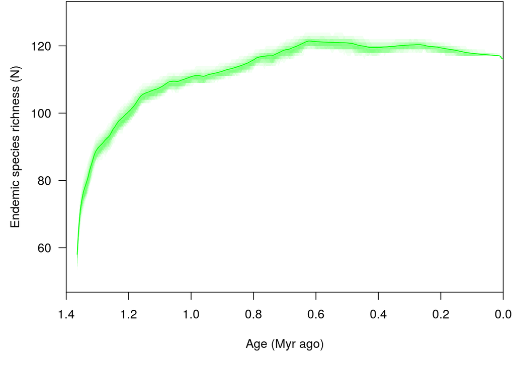

```r
Prob <- seq(0.95, 0.05, by = -0.05)
LttHpd <- vector(mode = "list", length(Prob))
for(i in 1:length(Prob)){
  LttHpd[[i]] <- apply(Ltt[-nrow(Ltt), ], 1, function(x) HPDinterval(coda:::mcmc(x), prob = Prob[i]))
}
MeanDiv <- rowMeans(Ltt[-nrow(Ltt), ])
TimeSeq <- seq(0, 13.7, 0.05) / 10

par(las = 1, mar = c(5.1, 4.5, 0.1, 0.8))
plot(seq(0, 14, 2)/10, rep(1, 8),
     type = "n", xaxs = "i",
     xlim = c(1.4, 0), ylim = c(50, 130),
     xlab = "Age (Myr ago)", ylab = "Endemic species richness (N)")
for(i in 1:length(Prob)){
  polygon(c(TimeSeq[-length(TimeSeq)], rev(TimeSeq[-length(TimeSeq)])),
          c(LttHpd[[i]][1, ], rev(LttHpd[[i]][2, ])),
          col = adjustcolor("green", alpha = 1/length(Prob)), border = NA)
}
lines(TimeSeq[-length(TimeSeq)], MeanDiv, col = "green")
```

### Plattform and resources

```r
Sys.time()
```

```
## [1] "2019-12-31 20:04:37 CET"
```